# Left Behind

Oct 2025A: Analysis

# Background

This is a pretest of local- and state-level races. We want to see which of the upcoming races (held on November 5th) features a candidate that is clearly seen as representing sweeping/radical change. To that end, we targeted residents of two states in which there are upcoming governor races (NJ and VA) and four cities in which there are upcoming mayoral races (NYC, Seattle, Minneapolis, and Cleveland).  
For each race, we asked the following about the top two polling candidates: (1) approach to change; (2) positions on cultural issues; and (3) positions on economic issues.  
We then asked about voting intention and political affiliation.

# Eligibility

We used prolific to target NJ and VA residents; and Connect to target NYC, Seattle, Minneapolis, and Cleveland residents. Eligible participants are those who are indeed residents of one of these places; ineligible participants were routed out after this initial prescreen.

```r
eligible_n <- df_lebe %>%
  group_by(is_elg) %>%
  summarise(n = n()) %>%
  ungroup() %>%
  filter(is_elg == 1) %>%
  select(n) %>%
  unlist() %>%
  unname()

df_lebe %>%
  group_by(is_elg) %>%
  summarise(N = n()) %>%
  ungroup() %>%
  mutate(Perc = round(100*(N/sum(N)),2)) %>%
  ungroup() %>%
  kbl() %>%
  kable_styling(bootstrap_options = "hover",
                full_width = F,
                position = "left")
```

| is_elg | N | Perc |
| --- | --- | --- |
| 0 | 14 | 5.96 |
| 1 | 221 | 94.04 |

That gives us a total of 221 eligible participants.

# Races

```r
df_lebe_elg %>%
  group_by(PLACENAME) %>%
  summarise(N = n()) %>%
  ungroup() %>%
  mutate(Perc = round(100*(N/sum(N)),2)) %>%
  ungroup() %>%
  arrange(desc(N)) %>%
  kbl() %>%
  kable_styling(bootstrap_options = "hover",
                full_width = F,
                position = "left")
```

| PLACENAME | N | Perc |
| --- | --- | --- |
| New Jersey | 50 | 22.62 |
| Virginia | 49 | 22.17 |
| New York City | 48 | 21.72 |
| Seattle | 29 | 13.12 |
| Minneapolis | 28 | 12.67 |
| Cleveland | 17 | 7.69 |

# Demographics

## Race

```r
df_lebe_elg %>%
  group_by(race) %>%
  summarise(N = n()) %>%
  ungroup() %>%
  mutate(Perc = round(100*(N/sum(N)),2)) %>%
  ungroup() %>%
  arrange(desc(N)) %>%
  kbl() %>%
  kable_styling(bootstrap_options = "hover",
                full_width = F,
                position = "left")
```

| race | N | Perc |
| --- | --- | --- |
| White | 136 | 61.54 |
| Asian | 29 | 13.12 |
| Black or African American | 29 | 13.12 |
| Hispanic, Latino, or Spanish origin | 11 | 4.98 |
| multiracial | 11 | 4.98 |
| Middle Eastern or North African | 2 | 0.90 |
| Other (please specify) | 2 | 0.90 |
| American Indian or Alaska Native | 1 | 0.45 |

## Gender

```r
df_lebe_elg %>%
  mutate(gender = ifelse(is.na(gender) | gender == "","other",gender)) %>%
  group_by(gender) %>%
  summarise(N = n()) %>%
  ungroup() %>%
  mutate(Perc = round(100*(N/sum(N)),2)) %>%
  ungroup() %>%
  arrange(desc(N)) %>%
  kbl() %>%
  kable_styling(bootstrap_options = "hover",
                full_width = F,
                position = "left")
```

| gender | N | Perc |
| --- | --- | --- |
| man | 117 | 52.94 |
| woman | 100 | 45.25 |
| other | 4 | 1.81 |

## Age

```r
df_lebe_elg %>%
  summarise(age_mean = round(mean(age,na.rm = T),2),
            age_sd = round(sd(age,na.rm = T),2)) %>%
  kbl() %>%
  kable_styling(bootstrap_options = "hover",
                full_width = F,
                position = "left")
```

| age_mean | age_sd |
| --- | --- |
| 39.92 | 12.82 |

## Education

```r
df_lebe_elg %>%
  group_by(edu) %>%
  summarise(N = n()) %>%
  ungroup() %>%
  mutate(Perc = round(100*(N/sum(N)),2)) %>%
  ungroup() %>%
  kbl() %>%
  kable_styling(bootstrap_options = "hover",
                full_width = F,
                position = "left")
```

| edu | N | Perc |
| --- | --- | --- |
| noHS | 2 | 0.90 |
| GED | 47 | 21.27 |
| 2yearColl | 24 | 10.86 |
| 4yearColl | 104 | 47.06 |
| MA | 39 | 17.65 |
| PHD | 5 | 2.26 |

## Income

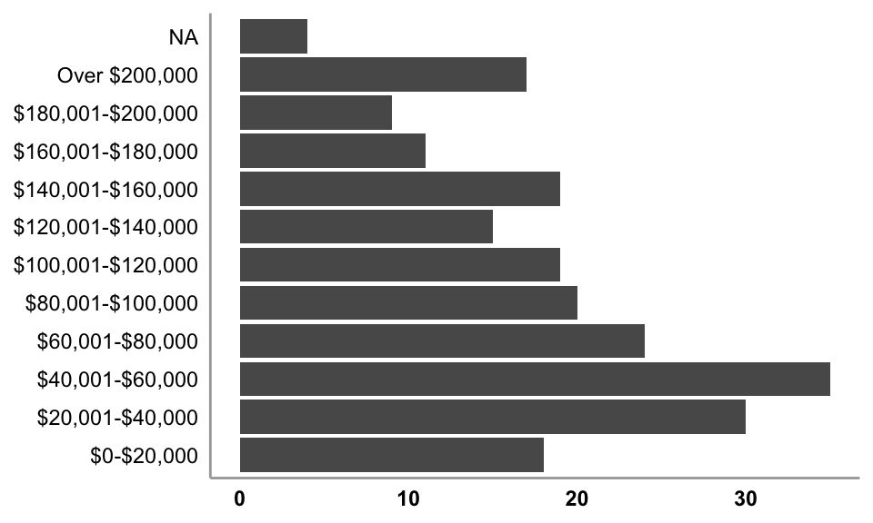

```r
df_lebe_elg %>%
  ggplot(aes(x = income)) +
  geom_bar() +
  theme(panel.grid.major = element_blank(),
        panel.grid.minor = element_blank(),
        panel.background = element_blank(),
        axis.ticks = element_blank(),
        axis.line = element_line(color = "grey66"),
        axis.text.y = element_text(color = "black"),
        axis.text.x = element_text(color = "black",
                                   face = "bold"),
        axis.title.x = element_blank(),
        axis.title.y = element_blank()) +
  coord_flip()
```

# Political profile

## Ideology

Please indicate your general political ideology (1 = *Extremely Liberal* to 7 = *Extremely Consevative*)

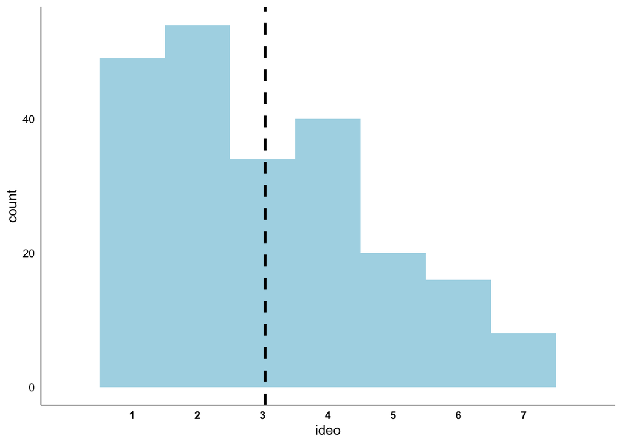

```r
df_lebe_elg %>%
  ggplot() +
  geom_histogram(aes(x = ideo), fill = "lightblue",color= NA,
                 binwidth = 1) +
  scale_x_continuous(limits = c(0,8),
                     breaks = seq(1,7,1)) +
  geom_vline(xintercept = mean(df_lebe_elg$ideo,na.rm = T),
             color = "black",
             linetype = "dashed",
             size = 1.1) +
  theme(panel.grid.major = element_blank(),
        panel.grid.minor = element_blank(),
        panel.background = element_blank(),
        axis.ticks = element_blank(),
        axis.line = element_line(color = "grey66"),
        axis.text.y = element_text(color = "black"),
        axis.text.x = element_text(color = "black",
                                   face = "bold"))
```

## Party ID

### Initial selection

```r
df_lebe_elg %>%
  group_by(party_gen) %>%
  summarise(N = n()) %>%
  ungroup() %>%
  mutate(Perc = round(100*(N/sum(N)),2)) %>%
  ungroup() %>%
  arrange(desc(N)) %>%
  kbl() %>%
  kable_styling(bootstrap_options = "hover",
                full_width = F,
                position = "left")
```

| party_gen | N | Perc |
| --- | --- | --- |
| Democrat | 123 | 55.66 |
| Independent | 49 | 22.17 |
| Republican | 37 | 16.74 |
| No preference | 10 | 4.52 |
| Other party | 2 | 0.90 |

### With followups

```r
df_lebe_elg %>%
  group_by(party_followup) %>%
  summarise(N = n()) %>%
  ungroup() %>%
  mutate(Perc = round(100*(N/sum(N)),2)) %>%
  ungroup() %>%
  kbl() %>%
  kable_styling(bootstrap_options = "hover",
                full_width = F,
                position = "left")
```

| party_followup | N | Perc |
| --- | --- | --- |
| Democrat \| Not very strong | 54 | 24.43 |
| Democrat \| Strong | 69 | 31.22 |
| Independent \| Closer to Democratic | 24 | 10.86 |
| Independent \| Closer to Republican | 8 | 3.62 |
| Independent \| Neither | 29 | 13.12 |
| Republican \| Not very strong | 17 | 7.69 |
| Republican \| Strong | 20 | 9.05 |

# Perception of Candidates

## New Jersey

### Approach to change

For each candidate, would you describe them as promising a **minor, incremental, and modest** change to how things are done in [PLACENAME] [state/city] government, or a **major, sweeping, and drastic** change in how things are done in [PLACENAME] [state/city] government? (1 = *Incremental* to 7 = *Sweeping*)

```r
df_lebe_elg %>%
  filter(PLACENAME == "New Jersey") %>%
  select(PID,CAND_1:CAND_2,cand1_change,cand2_change) %>%
  pivot_longer(-c(PID,cand1_change,cand2_change),
               names_to = "names",
               values_to = "candidate") %>%
  mutate(change = ifelse(names == "CAND_1",cand1_change,cand2_change)) %>%
  select(PID,candidate,change) %>%
  group_by(candidate) %>%
  summarise(n = n(),
            mean = mean(change,na.rm = T),
            sd = sd(change,na.rm = T)) %>%
  ungroup() %>%
  kbl() %>%
  kable_styling(bootstrap_options = "hover",
                full_width = F,
                position = "left")
```

| candidate | n | mean | sd |
| --- | --- | --- | --- |
| Jack Ciattarelli | 50 | 4.50 | 1.460361 |
| Mikie Sherill | 50 | 3.78 | 1.460919 |

```r
formodel <- df_lebe_elg %>%
  filter(PLACENAME == "New Jersey") %>%
  select(PID,CAND_1:CAND_2,cand1_change,cand2_change) %>%
  pivot_longer(-c(PID,cand1_change,cand2_change),
               names_to = "names",
               values_to = "candidate") %>%
  mutate(change = ifelse(names == "CAND_1",cand1_change,cand2_change)) %>%
  select(PID,candidate,change)

m1 <- rstatix::t_test(change ~ candidate,data = formodel,paired = T,detailed = T)
m2 <- rstatix::cohens_d(formodel,change ~ candidate,paired = T)

d = round(m2$effsize,2)

m1 %>%
  select(statistic,df,p,conf.low,conf.high) %>%
  mutate(d = d) %>%
    kbl() %>%
  kable_styling(bootstrap_options = "hover",
                full_width = F,
                position = "left")
```

| statistic | df | p | conf.low | conf.high | d |
| --- | --- | --- | --- | --- | --- |
| 2.281127 | 49 | 0.0269 | 0.0857108 | 1.354289 | 0.32 |

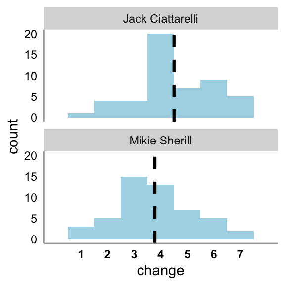

```r
means <- df_lebe_elg %>%
  filter(PLACENAME == "New Jersey") %>%
  select(PID,CAND_1:CAND_2,cand1_change,cand2_change) %>%
  pivot_longer(-c(PID,cand1_change,cand2_change),
               names_to = "names",
               values_to = "candidate") %>%
  mutate(change = ifelse(names == "CAND_1",cand1_change,cand2_change)) %>%
  select(PID,candidate,change) %>%
  group_by(candidate) %>%
  summarise(score = mean(change,na.rm = T)) %>%
  ungroup()

df_lebe_elg %>%
  filter(PLACENAME == "New Jersey") %>%
  select(PID,CAND_1:CAND_2,cand1_change,cand2_change) %>%
  pivot_longer(-c(PID,cand1_change,cand2_change),
               names_to = "names",
               values_to = "candidate") %>%
  mutate(change = ifelse(names == "CAND_1",cand1_change,cand2_change)) %>%
  select(PID,candidate,change) %>%
  ggplot() +
  geom_histogram(aes(x = change),
                 fill = "lightblue",
                 color = NA,
                 binwidth = 1) +
  scale_x_continuous(limits = c(0,8),
                     breaks = seq(1,7,1)) +
  geom_vline(data = means,mapping = aes(xintercept = score),
             color = "black",
             linetype = "dashed",
             size = 1.1) +
  theme(panel.grid.major = element_blank(),
        panel.grid.minor = element_blank(),
        panel.background = element_blank(),
        axis.ticks = element_blank(),
        axis.line = element_line(color = "grey66"),
        axis.text.y = element_text(color = "black"),
        axis.text.x = element_text(color = "black",
                                   face = "bold")) +
  facet_wrap(~candidate,nrow = 2)
```

### Cultural issues

What is their approach to cultural issues? Broadly, they may have a more **progressive approach** to cultural issues (pro-choice, minority rights, inclusive immigration) or a more **conservative approach** to cultural issues (pro-life, stronger police, immigration crackdown). (1 = *Progressive* to 7 = *Conservative*)

```r
df_lebe_elg %>%
  filter(PLACENAME == "New Jersey") %>%
  select(PID,CAND_1:CAND_2,cand1_cult,cand2_cult) %>%
  pivot_longer(-c(PID,cand1_cult,cand2_cult),
               names_to = "names",
               values_to = "candidate") %>%
  mutate(cult = ifelse(names == "CAND_1",cand1_cult,cand2_cult)) %>%
  select(PID,candidate,cult) %>%
  group_by(candidate) %>%
  summarise(n = n(),
            mean = mean(cult,na.rm = T),
            sd = sd(cult,na.rm = T)) %>%
  ungroup() %>%
  kbl() %>%
  kable_styling(bootstrap_options = "hover",
                full_width = F,
                position = "left")
```

| candidate | n | mean | sd |
| --- | --- | --- | --- |
| Jack Ciattarelli | 50 | 5.88 | 1.222911 |
| Mikie Sherill | 50 | 2.44 | 1.473023 |

```r
formodel <- df_lebe_elg %>%
  filter(PLACENAME == "New Jersey") %>%
  select(PID,CAND_1:CAND_2,cand1_cult,cand2_cult) %>%
  pivot_longer(-c(PID,cand1_cult,cand2_cult),
               names_to = "names",
               values_to = "candidate") %>%
  mutate(cult = ifelse(names == "CAND_1",cand1_cult,cand2_cult)) %>%
  select(PID,candidate,cult)

m1 <- rstatix::t_test(cult ~ candidate,data = formodel,paired = T,detailed = T)
m2 <- rstatix::cohens_d(formodel,cult ~ candidate,paired = T)

d = round(m2$effsize,2)

m1 %>%
  select(statistic,df,p,conf.low,conf.high) %>%
  mutate(d = d) %>%
    kbl() %>%
  kable_styling(bootstrap_options = "hover",
                full_width = F,
                position = "left")
```

| statistic | df | p | conf.low | conf.high | d |
| --- | --- | --- | --- | --- | --- |
| 10.59406 | 49 | 0 | 2.78747 | 4.09253 | 1.5 |

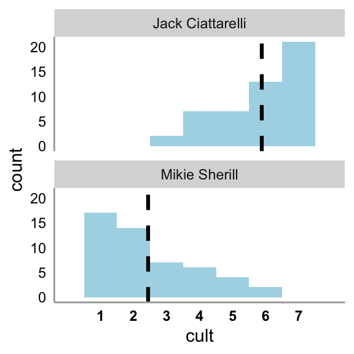

```r
means <- df_lebe_elg %>%
  filter(PLACENAME == "New Jersey") %>%
  select(PID,CAND_1:CAND_2,cand1_cult,cand2_cult) %>%
  pivot_longer(-c(PID,cand1_cult,cand2_cult),
               names_to = "names",
               values_to = "candidate") %>%
  mutate(cult = ifelse(names == "CAND_1",cand1_cult,cand2_cult)) %>%
  select(PID,candidate,cult) %>%
  group_by(candidate) %>%
  summarise(score = mean(cult,na.rm = T)) %>%
  ungroup()

df_lebe_elg %>%
  filter(PLACENAME == "New Jersey") %>%
  select(PID,CAND_1:CAND_2,cand1_cult,cand2_cult) %>%
  pivot_longer(-c(PID,cand1_cult,cand2_cult),
               names_to = "names",
               values_to = "candidate") %>%
  mutate(cult = ifelse(names == "CAND_1",cand1_cult,cand2_cult)) %>%
  select(PID,candidate,cult) %>%
  ggplot() +
  geom_histogram(aes(x = cult),
                 fill = "lightblue",
                 color = NA,
                 binwidth = 1) +
  scale_x_continuous(limits = c(0,8),
                     breaks = seq(1,7,1)) +
  geom_vline(data = means,mapping = aes(xintercept = score),
             color = "black",
             linetype = "dashed",
             size = 1.1) +
  theme(panel.grid.major = element_blank(),
        panel.grid.minor = element_blank(),
        panel.background = element_blank(),
        axis.ticks = element_blank(),
        axis.line = element_line(color = "grey66"),
        axis.text.y = element_text(color = "black"),
        axis.text.x = element_text(color = "black",
                                   face = "bold")) +
  facet_wrap(~candidate,nrow = 2)
```

### Economic policy

What is their approach to economic policy? Broadly, they may be supportive of more **redistributive** economic policies (high corporate taxes, stronger unions, welfare funding) or more **free-market** economic policies (low corporate taxes, deregulation, reducing government budget). (1 = *Redistributive* to 7 = *Free Market*)

```r
df_lebe_elg %>%
  filter(PLACENAME == "New Jersey") %>%
  select(PID,CAND_1:CAND_2,cand1_econ,cand2_econ) %>%
  pivot_longer(-c(PID,cand1_econ,cand2_econ),
               names_to = "names",
               values_to = "candidate") %>%
  mutate(econ = ifelse(names == "CAND_1",cand1_econ,cand2_econ)) %>%
  select(PID,candidate,econ) %>%
  group_by(candidate) %>%
  summarise(n = n(),
            mean = mean(econ,na.rm = T),
            sd = sd(econ,na.rm = T)) %>%
  ungroup() %>%
  kbl() %>%
  kable_styling(bootstrap_options = "hover",
                full_width = F,
                position = "left")
```

| candidate | n | mean | sd |
| --- | --- | --- | --- |
| Jack Ciattarelli | 50 | 5.48 | 1.668924 |
| Mikie Sherill | 50 | 3.06 | 1.405674 |

```r
formodel <- df_lebe_elg %>%
  filter(PLACENAME == "New Jersey") %>%
  select(PID,CAND_1:CAND_2,cand1_econ,cand2_econ) %>%
  pivot_longer(-c(PID,cand1_econ,cand2_econ),
               names_to = "names",
               values_to = "candidate") %>%
  mutate(econ = ifelse(names == "CAND_1",cand1_econ,cand2_econ)) %>%
  select(PID,candidate,econ)

m1 <- rstatix::t_test(econ ~ candidate,data = formodel,paired = T,detailed = T)
m2 <- rstatix::cohens_d(formodel,econ ~ candidate,paired = T)

d = round(m2$effsize,2)

m1 %>%
  select(statistic,df,p,conf.low,conf.high) %>%
  mutate(d = d) %>%
    kbl() %>%
  kable_styling(bootstrap_options = "hover",
                full_width = F,
                position = "left")
```

| statistic | df | p | conf.low | conf.high | d |
| --- | --- | --- | --- | --- | --- |
| 6.111264 | 49 | 2e-07 | 1.624228 | 3.215772 | 0.86 |

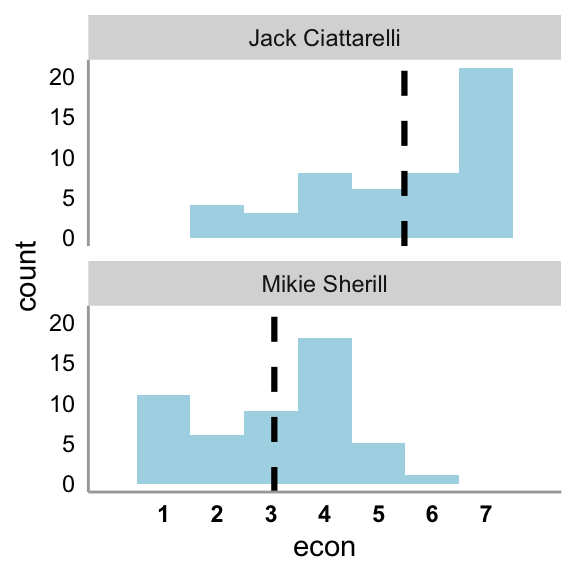

```r
means <- df_lebe_elg %>%
  filter(PLACENAME == "New Jersey") %>%
  select(PID,CAND_1:CAND_2,cand1_econ,cand2_econ) %>%
  pivot_longer(-c(PID,cand1_econ,cand2_econ),
               names_to = "names",
               values_to = "candidate") %>%
  mutate(econ = ifelse(names == "CAND_1",cand1_econ,cand2_econ)) %>%
  select(PID,candidate,econ) %>%
  group_by(candidate) %>%
  summarise(score = mean(econ,na.rm = T)) %>%
  ungroup()

df_lebe_elg %>%
  filter(PLACENAME == "New Jersey") %>%
  select(PID,CAND_1:CAND_2,cand1_econ,cand2_econ) %>%
  pivot_longer(-c(PID,cand1_econ,cand2_econ),
               names_to = "names",
               values_to = "candidate") %>%
  mutate(econ = ifelse(names == "CAND_1",cand1_econ,cand2_econ)) %>%
  select(PID,candidate,econ) %>%
  ggplot() +
  geom_histogram(aes(x = econ),
                 fill = "lightblue",
                 color = NA,
                 binwidth = 1) +
  scale_x_continuous(limits = c(0,8),
                     breaks = seq(1,7,1)) +
  geom_vline(data = means,mapping = aes(xintercept = score),
             color = "black",
             linetype = "dashed",
             size = 1.1) +
  theme(panel.grid.major = element_blank(),
        panel.grid.minor = element_blank(),
        panel.background = element_blank(),
        axis.ticks = element_blank(),
        axis.line = element_line(color = "grey66"),
        axis.text.y = element_text(color = "black"),
        axis.text.x = element_text(color = "black",
                                   face = "bold")) +
  facet_wrap(~candidate,nrow = 2)
```

## Virginia

### Approach to change

For each candidate, would you describe them as promising a **minor, incremental, and modest** change to how things are done in [PLACENAME] [state/city] government, or a **major, sweeping, and drastic** change in how things are done in [PLACENAME] [state/city] government? (1 = *Incremental* to 7 = *Sweeping*)

```r
df_lebe_elg %>%
  filter(PLACENAME == "Virginia") %>%
  select(PID,CAND_1:CAND_2,cand1_change,cand2_change) %>%
  pivot_longer(-c(PID,cand1_change,cand2_change),
               names_to = "names",
               values_to = "candidate") %>%
  mutate(change = ifelse(names == "CAND_1",cand1_change,cand2_change)) %>%
  select(PID,candidate,change) %>%
  group_by(candidate) %>%
  summarise(n = n(),
            mean = mean(change,na.rm = T),
            sd = sd(change,na.rm = T)) %>%
  ungroup() %>%
  kbl() %>%
  kable_styling(bootstrap_options = "hover",
                full_width = F,
                position = "left")
```

| candidate | n | mean | sd |
| --- | --- | --- | --- |
| Abigail Spanberger | 49 | 4.204082 | 1.554290 |
| Winsome Earle-Sears | 49 | 4.306122 | 1.758362 |

```r
formodel <- df_lebe_elg %>%
  filter(PLACENAME == "Virginia") %>%
  select(PID,CAND_1:CAND_2,cand1_change,cand2_change) %>%
  pivot_longer(-c(PID,cand1_change,cand2_change),
               names_to = "names",
               values_to = "candidate") %>%
  mutate(change = ifelse(names == "CAND_1",cand1_change,cand2_change)) %>%
  select(PID,candidate,change)

m1 <- rstatix::t_test(change ~ candidate,data = formodel,paired = T,detailed = T)
m2 <- rstatix::cohens_d(formodel,change ~ candidate,paired = T)

d = round(m2$effsize,2)

m1 %>%
  select(statistic,df,p,conf.low,conf.high) %>%
  mutate(d = d) %>%
    kbl() %>%
  kable_styling(bootstrap_options = "hover",
                full_width = F,
                position = "left")
```

| statistic | df | p | conf.low | conf.high | d |
| --- | --- | --- | --- | --- | --- |
| -0.2485287 | 48 | 0.805 | -0.9275664 | 0.7234848 | -0.04 |

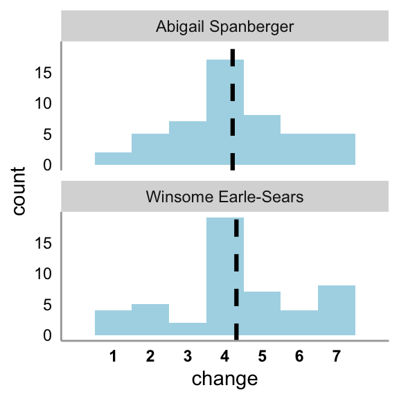

```r
means <- df_lebe_elg %>%
  filter(PLACENAME == "Virginia") %>%
  select(PID,CAND_1:CAND_2,cand1_change,cand2_change) %>%
  pivot_longer(-c(PID,cand1_change,cand2_change),
               names_to = "names",
               values_to = "candidate") %>%
  mutate(change = ifelse(names == "CAND_1",cand1_change,cand2_change)) %>%
  select(PID,candidate,change) %>%
  group_by(candidate) %>%
  summarise(score = mean(change,na.rm = T)) %>%
  ungroup()

df_lebe_elg %>%
  filter(PLACENAME == "Virginia") %>%
  select(PID,CAND_1:CAND_2,cand1_change,cand2_change) %>%
  pivot_longer(-c(PID,cand1_change,cand2_change),
               names_to = "names",
               values_to = "candidate") %>%
  mutate(change = ifelse(names == "CAND_1",cand1_change,cand2_change)) %>%
  select(PID,candidate,change) %>%
  ggplot() +
  geom_histogram(aes(x = change),
                 fill = "lightblue",
                 color = NA,
                 binwidth = 1) +
  scale_x_continuous(limits = c(0,8),
                     breaks = seq(1,7,1)) +
  geom_vline(data = means,mapping = aes(xintercept = score),
             color = "black",
             linetype = "dashed",
             size = 1.1) +
  theme(panel.grid.major = element_blank(),
        panel.grid.minor = element_blank(),
        panel.background = element_blank(),
        axis.ticks = element_blank(),
        axis.line = element_line(color = "grey66"),
        axis.text.y = element_text(color = "black"),
        axis.text.x = element_text(color = "black",
                                   face = "bold")) +
  facet_wrap(~candidate,nrow = 2)
```

### Cultural issues

What is their approach to cultural issues? Broadly, they may have a more **progressive approach** to cultural issues (pro-choice, minority rights, inclusive immigration) or a more **conservative approach** to cultural issues (pro-life, stronger police, immigration crackdown). (1 = *Progressive* to 7 = *Conservative*)

```r
df_lebe_elg %>%
  filter(PLACENAME == "Virginia") %>%
  select(PID,CAND_1:CAND_2,cand1_cult,cand2_cult) %>%
  pivot_longer(-c(PID,cand1_cult,cand2_cult),
               names_to = "names",
               values_to = "candidate") %>%
  mutate(cult = ifelse(names == "CAND_1",cand1_cult,cand2_cult)) %>%
  select(PID,candidate,cult) %>%
  group_by(candidate) %>%
  summarise(n = n(),
            mean = mean(cult,na.rm = T),
            sd = sd(cult,na.rm = T)) %>%
  ungroup() %>%
  kbl() %>%
  kable_styling(bootstrap_options = "hover",
                full_width = F,
                position = "left")
```

| candidate | n | mean | sd |
| --- | --- | --- | --- |
| Abigail Spanberger | 49 | 2.469388 | 1.595593 |
| Winsome Earle-Sears | 49 | 6.204082 | 1.098855 |

```r
formodel <- df_lebe_elg %>%
  filter(PLACENAME == "Virginia") %>%
  select(PID,CAND_1:CAND_2,cand1_cult,cand2_cult) %>%
  pivot_longer(-c(PID,cand1_cult,cand2_cult),
               names_to = "names",
               values_to = "candidate") %>%
  mutate(cult = ifelse(names == "CAND_1",cand1_cult,cand2_cult)) %>%
  select(PID,candidate,cult)

m1 <- rstatix::t_test(cult ~ candidate,data = formodel,paired = T,detailed = T)
m2 <- rstatix::cohens_d(formodel,cult ~ candidate,paired = T)

d = round(m2$effsize,2)

m1 %>%
  select(statistic,df,p,conf.low,conf.high) %>%
  mutate(d = d) %>%
    kbl() %>%
  kable_styling(bootstrap_options = "hover",
                full_width = F,
                position = "left")
```

| statistic | df | p | conf.low | conf.high | d |
| --- | --- | --- | --- | --- | --- |
| -10.83286 | 48 | 0 | -4.427872 | -3.041515 | -1.55 |

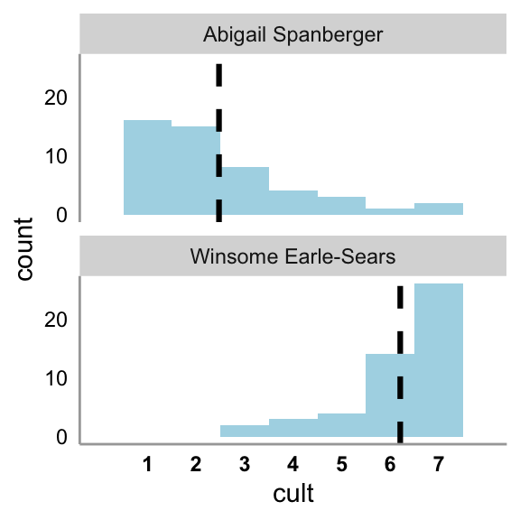

```r
means <- df_lebe_elg %>%
  filter(PLACENAME == "Virginia") %>%
  select(PID,CAND_1:CAND_2,cand1_cult,cand2_cult) %>%
  pivot_longer(-c(PID,cand1_cult,cand2_cult),
               names_to = "names",
               values_to = "candidate") %>%
  mutate(cult = ifelse(names == "CAND_1",cand1_cult,cand2_cult)) %>%
  select(PID,candidate,cult) %>%
  group_by(candidate) %>%
  summarise(score = mean(cult,na.rm = T)) %>%
  ungroup()

df_lebe_elg %>%
  filter(PLACENAME == "Virginia") %>%
  select(PID,CAND_1:CAND_2,cand1_cult,cand2_cult) %>%
  pivot_longer(-c(PID,cand1_cult,cand2_cult),
               names_to = "names",
               values_to = "candidate") %>%
  mutate(cult = ifelse(names == "CAND_1",cand1_cult,cand2_cult)) %>%
  select(PID,candidate,cult) %>%
  ggplot() +
  geom_histogram(aes(x = cult),
                 fill = "lightblue",
                 color = NA,
                 binwidth = 1) +
  scale_x_continuous(limits = c(0,8),
                     breaks = seq(1,7,1)) +
  geom_vline(data = means,mapping = aes(xintercept = score),
             color = "black",
             linetype = "dashed",
             size = 1.1) +
  theme(panel.grid.major = element_blank(),
        panel.grid.minor = element_blank(),
        panel.background = element_blank(),
        axis.ticks = element_blank(),
        axis.line = element_line(color = "grey66"),
        axis.text.y = element_text(color = "black"),
        axis.text.x = element_text(color = "black",
                                   face = "bold")) +
  facet_wrap(~candidate,nrow = 2)
```

### Economic policy

What is their approach to economic policy? Broadly, they may be supportive of more **redistributive** economic policies (high corporate taxes, stronger unions, welfare funding) or more **free-market** economic policies (low corporate taxes, deregulation, reducing government budget). (1 = *Redistributive* to 7 = *Free Market*)

```r
df_lebe_elg %>%
  filter(PLACENAME == "Virginia") %>%
  select(PID,CAND_1:CAND_2,cand1_econ,cand2_econ) %>%
  pivot_longer(-c(PID,cand1_econ,cand2_econ),
               names_to = "names",
               values_to = "candidate") %>%
  mutate(econ = ifelse(names == "CAND_1",cand1_econ,cand2_econ)) %>%
  select(PID,candidate,econ) %>%
  group_by(candidate) %>%
  summarise(n = n(),
            mean = mean(econ,na.rm = T),
            sd = sd(econ,na.rm = T)) %>%
  ungroup() %>%
  kbl() %>%
  kable_styling(bootstrap_options = "hover",
                full_width = F,
                position = "left")
```

| candidate | n | mean | sd |
| --- | --- | --- | --- |
| Abigail Spanberger | 49 | 3.265306 | 1.729348 |
| Winsome Earle-Sears | 49 | 5.367347 | 1.481748 |

```r
formodel <- df_lebe_elg %>%
  filter(PLACENAME == "Virginia") %>%
  select(PID,CAND_1:CAND_2,cand1_econ,cand2_econ) %>%
  pivot_longer(-c(PID,cand1_econ,cand2_econ),
               names_to = "names",
               values_to = "candidate") %>%
  mutate(econ = ifelse(names == "CAND_1",cand1_econ,cand2_econ)) %>%
  select(PID,candidate,econ)

m1 <- rstatix::t_test(econ ~ candidate,data = formodel,paired = T,detailed = T)
m2 <- rstatix::cohens_d(formodel,econ ~ candidate,paired = T)

d = round(m2$effsize,2)

m1 %>%
  select(statistic,df,p,conf.low,conf.high) %>%
  mutate(d = d) %>%
    kbl() %>%
  kable_styling(bootstrap_options = "hover",
                full_width = F,
                position = "left")
```

| statistic | df | p | conf.low | conf.high | d |
| --- | --- | --- | --- | --- | --- |
| -5.019416 | 48 | 7.5e-06 | -2.944058 | -1.260023 | -0.72 |

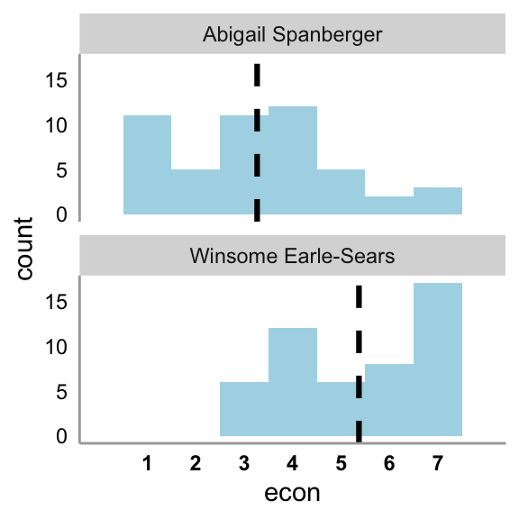

```r
means <- df_lebe_elg %>%
  filter(PLACENAME == "Virginia") %>%
  select(PID,CAND_1:CAND_2,cand1_econ,cand2_econ) %>%
  pivot_longer(-c(PID,cand1_econ,cand2_econ),
               names_to = "names",
               values_to = "candidate") %>%
  mutate(econ = ifelse(names == "CAND_1",cand1_econ,cand2_econ)) %>%
  select(PID,candidate,econ) %>%
  group_by(candidate) %>%
  summarise(score = mean(econ,na.rm = T)) %>%
  ungroup()

df_lebe_elg %>%
  filter(PLACENAME == "Virginia") %>%
  select(PID,CAND_1:CAND_2,cand1_econ,cand2_econ) %>%
  pivot_longer(-c(PID,cand1_econ,cand2_econ),
               names_to = "names",
               values_to = "candidate") %>%
  mutate(econ = ifelse(names == "CAND_1",cand1_econ,cand2_econ)) %>%
  select(PID,candidate,econ) %>%
  ggplot() +
  geom_histogram(aes(x = econ),
                 fill = "lightblue",
                 color = NA,
                 binwidth = 1) +
  scale_x_continuous(limits = c(0,8),
                     breaks = seq(1,7,1)) +
  geom_vline(data = means,mapping = aes(xintercept = score),
             color = "black",
             linetype = "dashed",
             size = 1.1) +
  theme(panel.grid.major = element_blank(),
        panel.grid.minor = element_blank(),
        panel.background = element_blank(),
        axis.ticks = element_blank(),
        axis.line = element_line(color = "grey66"),
        axis.text.y = element_text(color = "black"),
        axis.text.x = element_text(color = "black",
                                   face = "bold")) +
  facet_wrap(~candidate,nrow = 2)
```

## New York City

### Approach to change

For each candidate, would you describe them as promising a **minor, incremental, and modest** change to how things are done in [PLACENAME] [state/city] government, or a **major, sweeping, and drastic** change in how things are done in [PLACENAME] [state/city] government? (1 = *Incremental* to 7 = *Sweeping*)

```r
df_lebe_elg %>%
  filter(PLACENAME == "New York City") %>%
  select(PID,CAND_1:CAND_2,cand1_change,cand2_change) %>%
  pivot_longer(-c(PID,cand1_change,cand2_change),
               names_to = "names",
               values_to = "candidate") %>%
  mutate(change = ifelse(names == "CAND_1",cand1_change,cand2_change)) %>%
  select(PID,candidate,change) %>%
  group_by(candidate) %>%
  summarise(n = n(),
            mean = mean(change,na.rm = T),
            sd = sd(change,na.rm = T)) %>%
  ungroup() %>%
  kbl() %>%
  kable_styling(bootstrap_options = "hover",
                full_width = F,
                position = "left")
```

| candidate | n | mean | sd |
| --- | --- | --- | --- |
| Andrew Cuomo | 48 | 2.520833 | 1.529700 |
| Zohran Mamdani | 48 | 5.437500 | 1.486195 |

```r
formodel <- df_lebe_elg %>%
  filter(PLACENAME == "New York City") %>%
  select(PID,CAND_1:CAND_2,cand1_change,cand2_change) %>%
  pivot_longer(-c(PID,cand1_change,cand2_change),
               names_to = "names",
               values_to = "candidate") %>%
  mutate(change = ifelse(names == "CAND_1",cand1_change,cand2_change)) %>%
  select(PID,candidate,change)

m1 <- rstatix::t_test(change ~ candidate,data = formodel,paired = T,detailed = T)
m2 <- rstatix::cohens_d(formodel,change ~ candidate,paired = T)

d = round(m2$effsize,2)

m1 %>%
  select(statistic,df,p,conf.low,conf.high) %>%
  mutate(d = d) %>%
    kbl() %>%
  kable_styling(bootstrap_options = "hover",
                full_width = F,
                position = "left")
```

| statistic | df | p | conf.low | conf.high | d |
| --- | --- | --- | --- | --- | --- |
| -8.436119 | 47 | 0 | -3.612197 | -2.221136 | -1.22 |

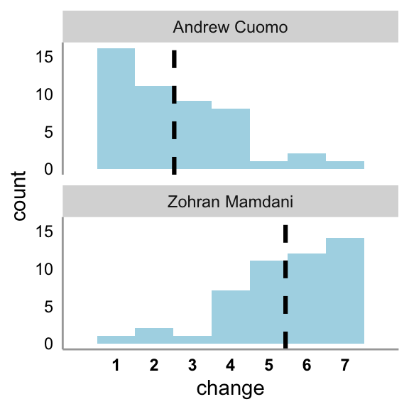

```r
means <- df_lebe_elg %>%
  filter(PLACENAME == "New York City") %>%
  select(PID,CAND_1:CAND_2,cand1_change,cand2_change) %>%
  pivot_longer(-c(PID,cand1_change,cand2_change),
               names_to = "names",
               values_to = "candidate") %>%
  mutate(change = ifelse(names == "CAND_1",cand1_change,cand2_change)) %>%
  select(PID,candidate,change) %>%
  group_by(candidate) %>%
  summarise(score = mean(change,na.rm = T)) %>%
  ungroup()

df_lebe_elg %>%
  filter(PLACENAME == "New York City") %>%
  select(PID,CAND_1:CAND_2,cand1_change,cand2_change) %>%
  pivot_longer(-c(PID,cand1_change,cand2_change),
               names_to = "names",
               values_to = "candidate") %>%
  mutate(change = ifelse(names == "CAND_1",cand1_change,cand2_change)) %>%
  select(PID,candidate,change) %>%
  ggplot() +
  geom_histogram(aes(x = change),
                 fill = "lightblue",
                 color = NA,
                 binwidth = 1) +
  scale_x_continuous(limits = c(0,8),
                     breaks = seq(1,7,1)) +
  geom_vline(data = means,mapping = aes(xintercept = score),
             color = "black",
             linetype = "dashed",
             size = 1.1) +
  theme(panel.grid.major = element_blank(),
        panel.grid.minor = element_blank(),
        panel.background = element_blank(),
        axis.ticks = element_blank(),
        axis.line = element_line(color = "grey66"),
        axis.text.y = element_text(color = "black"),
        axis.text.x = element_text(color = "black",
                                   face = "bold")) +
  facet_wrap(~candidate,nrow = 2)
```

### Cultural issues

What is their approach to cultural issues? Broadly, they may have a more **progressive approach** to cultural issues (pro-choice, minority rights, inclusive immigration) or a more **conservative approach** to cultural issues (pro-life, stronger police, immigration crackdown). (1 = *Progressive* to 7 = *Conservative*)

```r
df_lebe_elg %>%
  filter(PLACENAME == "New York City") %>%
  select(PID,CAND_1:CAND_2,cand1_cult,cand2_cult) %>%
  pivot_longer(-c(PID,cand1_cult,cand2_cult),
               names_to = "names",
               values_to = "candidate") %>%
  mutate(cult = ifelse(names == "CAND_1",cand1_cult,cand2_cult)) %>%
  select(PID,candidate,cult) %>%
  group_by(candidate) %>%
  summarise(n = n(),
            mean = mean(cult,na.rm = T),
            sd = sd(cult,na.rm = T)) %>%
  ungroup() %>%
  kbl() %>%
  kable_styling(bootstrap_options = "hover",
                full_width = F,
                position = "left")
```

| candidate | n | mean | sd |
| --- | --- | --- | --- |
| Andrew Cuomo | 48 | 4.7500 | 1.344809 |
| Zohran Mamdani | 48 | 1.6875 | 1.355152 |

```r
formodel <- df_lebe_elg %>%
  filter(PLACENAME == "New York City") %>%
  select(PID,CAND_1:CAND_2,cand1_cult,cand2_cult) %>%
  pivot_longer(-c(PID,cand1_cult,cand2_cult),
               names_to = "names",
               values_to = "candidate") %>%
  mutate(cult = ifelse(names == "CAND_1",cand1_cult,cand2_cult)) %>%
  select(PID,candidate,cult)

m1 <- rstatix::t_test(cult ~ candidate,data = formodel,paired = T,detailed = T)
m2 <- rstatix::cohens_d(formodel,cult ~ candidate,paired = T)

d = round(m2$effsize,2)

m1 %>%
  select(statistic,df,p,conf.low,conf.high) %>%
  mutate(d = d) %>%
    kbl() %>%
  kable_styling(bootstrap_options = "hover",
                full_width = F,
                position = "left")
```

| statistic | df | p | conf.low | conf.high | d |
| --- | --- | --- | --- | --- | --- |
| 10.26479 | 47 | 0 | 2.462298 | 3.662702 | 1.48 |

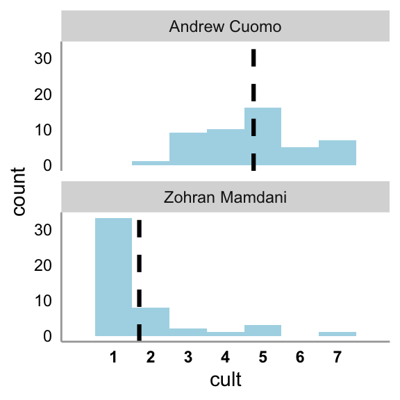

```r
means <- df_lebe_elg %>%
  filter(PLACENAME == "New York City") %>%
  select(PID,CAND_1:CAND_2,cand1_cult,cand2_cult) %>%
  pivot_longer(-c(PID,cand1_cult,cand2_cult),
               names_to = "names",
               values_to = "candidate") %>%
  mutate(cult = ifelse(names == "CAND_1",cand1_cult,cand2_cult)) %>%
  select(PID,candidate,cult) %>%
  group_by(candidate) %>%
  summarise(score = mean(cult,na.rm = T)) %>%
  ungroup()

df_lebe_elg %>%
  filter(PLACENAME == "New York City") %>%
  select(PID,CAND_1:CAND_2,cand1_cult,cand2_cult) %>%
  pivot_longer(-c(PID,cand1_cult,cand2_cult),
               names_to = "names",
               values_to = "candidate") %>%
  mutate(cult = ifelse(names == "CAND_1",cand1_cult,cand2_cult)) %>%
  select(PID,candidate,cult) %>%
  ggplot() +
  geom_histogram(aes(x = cult),
                 fill = "lightblue",
                 color = NA,
                 binwidth = 1) +
  scale_x_continuous(limits = c(0,8),
                     breaks = seq(1,7,1)) +
  geom_vline(data = means,mapping = aes(xintercept = score),
             color = "black",
             linetype = "dashed",
             size = 1.1) +
  theme(panel.grid.major = element_blank(),
        panel.grid.minor = element_blank(),
        panel.background = element_blank(),
        axis.ticks = element_blank(),
        axis.line = element_line(color = "grey66"),
        axis.text.y = element_text(color = "black"),
        axis.text.x = element_text(color = "black",
                                   face = "bold")) +
  facet_wrap(~candidate,nrow = 2)
```

### Economic policy

What is their approach to economic policy? Broadly, they may be supportive of more **redistributive** economic policies (high corporate taxes, stronger unions, welfare funding) or more **free-market** economic policies (low corporate taxes, deregulation, reducing government budget). (1 = *Redistributive* to 7 = *Free Market*)

```r
df_lebe_elg %>%
  filter(PLACENAME == "New York City") %>%
  select(PID,CAND_1:CAND_2,cand1_econ,cand2_econ) %>%
  pivot_longer(-c(PID,cand1_econ,cand2_econ),
               names_to = "names",
               values_to = "candidate") %>%
  mutate(econ = ifelse(names == "CAND_1",cand1_econ,cand2_econ)) %>%
  select(PID,candidate,econ) %>%
  group_by(candidate) %>%
  summarise(n = n(),
            mean = mean(econ,na.rm = T),
            sd = sd(econ,na.rm = T)) %>%
  ungroup() %>%
  kbl() %>%
  kable_styling(bootstrap_options = "hover",
                full_width = F,
                position = "left")
```

| candidate | n | mean | sd |
| --- | --- | --- | --- |
| Andrew Cuomo | 48 | 5.062500 | 1.244670 |
| Zohran Mamdani | 48 | 2.520833 | 1.688378 |

```r
formodel <- df_lebe_elg %>%
  filter(PLACENAME == "New York City") %>%
  select(PID,CAND_1:CAND_2,cand1_econ,cand2_econ) %>%
  pivot_longer(-c(PID,cand1_econ,cand2_econ),
               names_to = "names",
               values_to = "candidate") %>%
  mutate(econ = ifelse(names == "CAND_1",cand1_econ,cand2_econ)) %>%
  select(PID,candidate,econ)

m1 <- rstatix::t_test(econ ~ candidate,data = formodel,paired = T,detailed = T)
m2 <- rstatix::cohens_d(formodel,econ ~ candidate,paired = T)

d = round(m2$effsize,2)

m1 %>%
  select(statistic,df,p,conf.low,conf.high) %>%
  mutate(d = d) %>%
    kbl() %>%
  kable_styling(bootstrap_options = "hover",
                full_width = F,
                position = "left")
```

| statistic | df | p | conf.low | conf.high | d |
| --- | --- | --- | --- | --- | --- |
| 6.770668 | 47 | 0 | 1.786472 | 3.296862 | 0.98 |

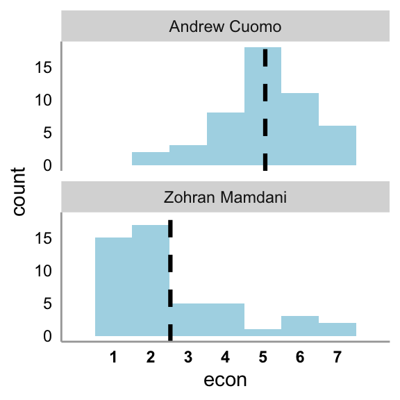

```r
means <- df_lebe_elg %>%
  filter(PLACENAME == "New York City") %>%
  select(PID,CAND_1:CAND_2,cand1_econ,cand2_econ) %>%
  pivot_longer(-c(PID,cand1_econ,cand2_econ),
               names_to = "names",
               values_to = "candidate") %>%
  mutate(econ = ifelse(names == "CAND_1",cand1_econ,cand2_econ)) %>%
  select(PID,candidate,econ) %>%
  group_by(candidate) %>%
  summarise(score = mean(econ,na.rm = T)) %>%
  ungroup()

df_lebe_elg %>%
  filter(PLACENAME == "New York City") %>%
  select(PID,CAND_1:CAND_2,cand1_econ,cand2_econ) %>%
  pivot_longer(-c(PID,cand1_econ,cand2_econ),
               names_to = "names",
               values_to = "candidate") %>%
  mutate(econ = ifelse(names == "CAND_1",cand1_econ,cand2_econ)) %>%
  select(PID,candidate,econ) %>%
  ggplot() +
  geom_histogram(aes(x = econ),
                 fill = "lightblue",
                 color = NA,
                 binwidth = 1) +
  scale_x_continuous(limits = c(0,8),
                     breaks = seq(1,7,1)) +
  geom_vline(data = means,mapping = aes(xintercept = score),
             color = "black",
             linetype = "dashed",
             size = 1.1) +
  theme(panel.grid.major = element_blank(),
        panel.grid.minor = element_blank(),
        panel.background = element_blank(),
        axis.ticks = element_blank(),
        axis.line = element_line(color = "grey66"),
        axis.text.y = element_text(color = "black"),
        axis.text.x = element_text(color = "black",
                                   face = "bold")) +
  facet_wrap(~candidate,nrow = 2)
```

## Seattle

### Approach to change

For each candidate, would you describe them as promising a **minor, incremental, and modest** change to how things are done in [PLACENAME] [state/city] government, or a **major, sweeping, and drastic** change in how things are done in [PLACENAME] [state/city] government? (1 = *Incremental* to 7 = *Sweeping*)

```r
df_lebe_elg %>%
  filter(PLACENAME == "Seattle") %>%
  select(PID,CAND_1:CAND_2,cand1_change,cand2_change) %>%
  pivot_longer(-c(PID,cand1_change,cand2_change),
               names_to = "names",
               values_to = "candidate") %>%
  mutate(change = ifelse(names == "CAND_1",cand1_change,cand2_change)) %>%
  select(PID,candidate,change) %>%
  group_by(candidate) %>%
  summarise(n = n(),
            mean = mean(change,na.rm = T),
            sd = sd(change,na.rm = T)) %>%
  ungroup() %>%
  kbl() %>%
  kable_styling(bootstrap_options = "hover",
                full_width = F,
                position = "left")
```

| candidate | n | mean | sd |
| --- | --- | --- | --- |
| Bruce Harrell | 29 | 3.068966 | 1.486392 |
| Katie Wilson | 29 | 4.689655 | 1.514300 |

```r
formodel <- df_lebe_elg %>%
  filter(PLACENAME == "Seattle") %>%
  select(PID,CAND_1:CAND_2,cand1_change,cand2_change) %>%
  pivot_longer(-c(PID,cand1_change,cand2_change),
               names_to = "names",
               values_to = "candidate") %>%
  mutate(change = ifelse(names == "CAND_1",cand1_change,cand2_change)) %>%
  select(PID,candidate,change)

m1 <- rstatix::t_test(change ~ candidate,data = formodel,paired = T,detailed = T)
m2 <- rstatix::cohens_d(formodel,change ~ candidate,paired = T)

d = round(m2$effsize,2)

m1 %>%
  select(statistic,df,p,conf.low,conf.high) %>%
  mutate(d = d) %>%
    kbl() %>%
  kable_styling(bootstrap_options = "hover",
                full_width = F,
                position = "left")
```

| statistic | df | p | conf.low | conf.high | d |
| --- | --- | --- | --- | --- | --- |
| -4.309777 | 28 | 0.000182 | -2.390992 | -0.850387 | -0.8 |

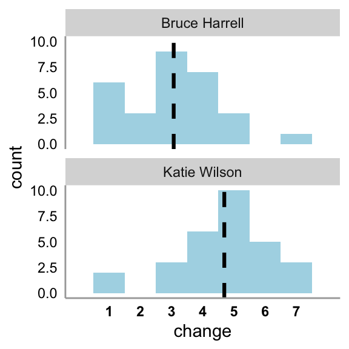

```r
means <- df_lebe_elg %>%
  filter(PLACENAME == "Seattle") %>%
  select(PID,CAND_1:CAND_2,cand1_change,cand2_change) %>%
  pivot_longer(-c(PID,cand1_change,cand2_change),
               names_to = "names",
               values_to = "candidate") %>%
  mutate(change = ifelse(names == "CAND_1",cand1_change,cand2_change)) %>%
  select(PID,candidate,change) %>%
  group_by(candidate) %>%
  summarise(score = mean(change,na.rm = T)) %>%
  ungroup()

df_lebe_elg %>%
  filter(PLACENAME == "Seattle") %>%
  select(PID,CAND_1:CAND_2,cand1_change,cand2_change) %>%
  pivot_longer(-c(PID,cand1_change,cand2_change),
               names_to = "names",
               values_to = "candidate") %>%
  mutate(change = ifelse(names == "CAND_1",cand1_change,cand2_change)) %>%
  select(PID,candidate,change) %>%
  ggplot() +
  geom_histogram(aes(x = change),
                 fill = "lightblue",
                 color = NA,
                 binwidth = 1) +
  scale_x_continuous(limits = c(0,8),
                     breaks = seq(1,7,1)) +
  geom_vline(data = means,mapping = aes(xintercept = score),
             color = "black",
             linetype = "dashed",
             size = 1.1) +
  theme(panel.grid.major = element_blank(),
        panel.grid.minor = element_blank(),
        panel.background = element_blank(),
        axis.ticks = element_blank(),
        axis.line = element_line(color = "grey66"),
        axis.text.y = element_text(color = "black"),
        axis.text.x = element_text(color = "black",
                                   face = "bold")) +
  facet_wrap(~candidate,nrow = 2)
```

### Cultural issues

What is their approach to cultural issues? Broadly, they may have a more **progressive approach** to cultural issues (pro-choice, minority rights, inclusive immigration) or a more **conservative approach** to cultural issues (pro-life, stronger police, immigration crackdown). (1 = *Progressive* to 7 = *Conservative*)

```r
df_lebe_elg %>%
  filter(PLACENAME == "Seattle") %>%
  select(PID,CAND_1:CAND_2,cand1_cult,cand2_cult) %>%
  pivot_longer(-c(PID,cand1_cult,cand2_cult),
               names_to = "names",
               values_to = "candidate") %>%
  mutate(cult = ifelse(names == "CAND_1",cand1_cult,cand2_cult)) %>%
  select(PID,candidate,cult) %>%
  group_by(candidate) %>%
  summarise(n = n(),
            mean = mean(cult,na.rm = T),
            sd = sd(cult,na.rm = T)) %>%
  ungroup() %>%
  kbl() %>%
  kable_styling(bootstrap_options = "hover",
                full_width = F,
                position = "left")
```

| candidate | n | mean | sd |
| --- | --- | --- | --- |
| Bruce Harrell | 29 | 3.724138 | 1.645265 |
| Katie Wilson | 29 | 2.655172 | 1.798330 |

```r
formodel <- df_lebe_elg %>%
  filter(PLACENAME == "Seattle") %>%
  select(PID,CAND_1:CAND_2,cand1_cult,cand2_cult) %>%
  pivot_longer(-c(PID,cand1_cult,cand2_cult),
               names_to = "names",
               values_to = "candidate") %>%
  mutate(cult = ifelse(names == "CAND_1",cand1_cult,cand2_cult)) %>%
  select(PID,candidate,cult)

m1 <- rstatix::t_test(cult ~ candidate,data = formodel,paired = T,detailed = T)
m2 <- rstatix::cohens_d(formodel,cult ~ candidate,paired = T)

d = round(m2$effsize,2)

m1 %>%
  select(statistic,df,p,conf.low,conf.high) %>%
  mutate(d = d) %>%
    kbl() %>%
  kable_styling(bootstrap_options = "hover",
                full_width = F,
                position = "left")
```

| statistic | df | p | conf.low | conf.high | d |
| --- | --- | --- | --- | --- | --- |
| 2.8299 | 28 | 0.00852 | 0.2952008 | 1.84273 | 0.53 |

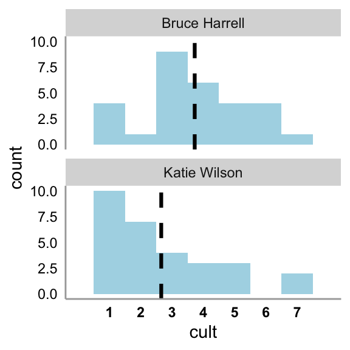

```r
means <- df_lebe_elg %>%
  filter(PLACENAME == "Seattle") %>%
  select(PID,CAND_1:CAND_2,cand1_cult,cand2_cult) %>%
  pivot_longer(-c(PID,cand1_cult,cand2_cult),
               names_to = "names",
               values_to = "candidate") %>%
  mutate(cult = ifelse(names == "CAND_1",cand1_cult,cand2_cult)) %>%
  select(PID,candidate,cult) %>%
  group_by(candidate) %>%
  summarise(score = mean(cult,na.rm = T)) %>%
  ungroup()

df_lebe_elg %>%
  filter(PLACENAME == "Seattle") %>%
  select(PID,CAND_1:CAND_2,cand1_cult,cand2_cult) %>%
  pivot_longer(-c(PID,cand1_cult,cand2_cult),
               names_to = "names",
               values_to = "candidate") %>%
  mutate(cult = ifelse(names == "CAND_1",cand1_cult,cand2_cult)) %>%
  select(PID,candidate,cult) %>%
  ggplot() +
  geom_histogram(aes(x = cult),
                 fill = "lightblue",
                 color = NA,
                 binwidth = 1) +
  scale_x_continuous(limits = c(0,8),
                     breaks = seq(1,7,1)) +
  geom_vline(data = means,mapping = aes(xintercept = score),
             color = "black",
             linetype = "dashed",
             size = 1.1) +
  theme(panel.grid.major = element_blank(),
        panel.grid.minor = element_blank(),
        panel.background = element_blank(),
        axis.ticks = element_blank(),
        axis.line = element_line(color = "grey66"),
        axis.text.y = element_text(color = "black"),
        axis.text.x = element_text(color = "black",
                                   face = "bold")) +
  facet_wrap(~candidate,nrow = 2)
```

### Economic policy

What is their approach to economic policy? Broadly, they may be supportive of more **redistributive** economic policies (high corporate taxes, stronger unions, welfare funding) or more **free-market** economic policies (low corporate taxes, deregulation, reducing government budget). (1 = *Redistributive* to 7 = *Free Market*)

```r
df_lebe_elg %>%
  filter(PLACENAME == "Seattle") %>%
  select(PID,CAND_1:CAND_2,cand1_econ,cand2_econ) %>%
  pivot_longer(-c(PID,cand1_econ,cand2_econ),
               names_to = "names",
               values_to = "candidate") %>%
  mutate(econ = ifelse(names == "CAND_1",cand1_econ,cand2_econ)) %>%
  select(PID,candidate,econ) %>%
  group_by(candidate) %>%
  summarise(n = n(),
            mean = mean(econ,na.rm = T),
            sd = sd(econ,na.rm = T)) %>%
  ungroup() %>%
  kbl() %>%
  kable_styling(bootstrap_options = "hover",
                full_width = F,
                position = "left")
```

| candidate | n | mean | sd |
| --- | --- | --- | --- |
| Bruce Harrell | 29 | 3.620690 | 1.497946 |
| Katie Wilson | 29 | 3.137931 | 1.505327 |

```r
formodel <- df_lebe_elg %>%
  filter(PLACENAME == "Seattle") %>%
  select(PID,CAND_1:CAND_2,cand1_econ,cand2_econ) %>%
  pivot_longer(-c(PID,cand1_econ,cand2_econ),
               names_to = "names",
               values_to = "candidate") %>%
  mutate(econ = ifelse(names == "CAND_1",cand1_econ,cand2_econ)) %>%
  select(PID,candidate,econ)

m1 <- rstatix::t_test(econ ~ candidate,data = formodel,paired = T,detailed = T)
m2 <- rstatix::cohens_d(formodel,econ ~ candidate,paired = T)

d = round(m2$effsize,2)

m1 %>%
  select(statistic,df,p,conf.low,conf.high) %>%
  mutate(d = d) %>%
    kbl() %>%
  kable_styling(bootstrap_options = "hover",
                full_width = F,
                position = "left")
```

| statistic | df | p | conf.low | conf.high | d |
| --- | --- | --- | --- | --- | --- |
| 1.157516 | 28 | 0.257 | -0.3715588 | 1.337076 | 0.21 |

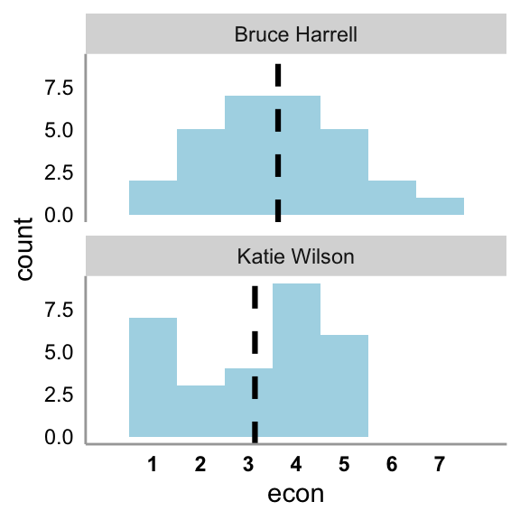

```r
means <- df_lebe_elg %>%
  filter(PLACENAME == "Seattle") %>%
  select(PID,CAND_1:CAND_2,cand1_econ,cand2_econ) %>%
  pivot_longer(-c(PID,cand1_econ,cand2_econ),
               names_to = "names",
               values_to = "candidate") %>%
  mutate(econ = ifelse(names == "CAND_1",cand1_econ,cand2_econ)) %>%
  select(PID,candidate,econ) %>%
  group_by(candidate) %>%
  summarise(score = mean(econ,na.rm = T)) %>%
  ungroup()

df_lebe_elg %>%
  filter(PLACENAME == "Seattle") %>%
  select(PID,CAND_1:CAND_2,cand1_econ,cand2_econ) %>%
  pivot_longer(-c(PID,cand1_econ,cand2_econ),
               names_to = "names",
               values_to = "candidate") %>%
  mutate(econ = ifelse(names == "CAND_1",cand1_econ,cand2_econ)) %>%
  select(PID,candidate,econ) %>%
  ggplot() +
  geom_histogram(aes(x = econ),
                 fill = "lightblue",
                 color = NA,
                 binwidth = 1) +
  scale_x_continuous(limits = c(0,8),
                     breaks = seq(1,7,1)) +
  geom_vline(data = means,mapping = aes(xintercept = score),
             color = "black",
             linetype = "dashed",
             size = 1.1) +
  theme(panel.grid.major = element_blank(),
        panel.grid.minor = element_blank(),
        panel.background = element_blank(),
        axis.ticks = element_blank(),
        axis.line = element_line(color = "grey66"),
        axis.text.y = element_text(color = "black"),
        axis.text.x = element_text(color = "black",
                                   face = "bold")) +
  facet_wrap(~candidate,nrow = 2)
```

## Minneapolis

### Approach to change

For each candidate, would you describe them as promising a **minor, incremental, and modest** change to how things are done in [PLACENAME] [state/city] government, or a **major, sweeping, and drastic** change in how things are done in [PLACENAME] [state/city] government? (1 = *Incremental* to 7 = *Sweeping*)

```r
df_lebe_elg %>%
  filter(PLACENAME == "Minneapolis") %>%
  select(PID,CAND_1:CAND_2,cand1_change,cand2_change) %>%
  pivot_longer(-c(PID,cand1_change,cand2_change),
               names_to = "names",
               values_to = "candidate") %>%
  mutate(change = ifelse(names == "CAND_1",cand1_change,cand2_change)) %>%
  select(PID,candidate,change) %>%
  group_by(candidate) %>%
  summarise(n = n(),
            mean = mean(change,na.rm = T),
            sd = sd(change,na.rm = T)) %>%
  ungroup() %>%
  kbl() %>%
  kable_styling(bootstrap_options = "hover",
                full_width = F,
                position = "left")
```

| candidate | n | mean | sd |
| --- | --- | --- | --- |
| Jacob Frey | 28 | 2.821429 | 1.588234 |
| Omar Fateh | 28 | 4.714286 | 1.739671 |

```r
formodel <- df_lebe_elg %>%
  filter(PLACENAME == "Minneapolis") %>%
  select(PID,CAND_1:CAND_2,cand1_change,cand2_change) %>%
  pivot_longer(-c(PID,cand1_change,cand2_change),
               names_to = "names",
               values_to = "candidate") %>%
  mutate(change = ifelse(names == "CAND_1",cand1_change,cand2_change)) %>%
  select(PID,candidate,change)

m1 <- rstatix::t_test(change ~ candidate,data = formodel,paired = T,detailed = T)
m2 <- rstatix::cohens_d(formodel,change ~ candidate,paired = T)

d = round(m2$effsize,2)

m1 %>%
  select(statistic,df,p,conf.low,conf.high) %>%
  mutate(d = d) %>%
    kbl() %>%
  kable_styling(bootstrap_options = "hover",
                full_width = F,
                position = "left")
```

| statistic | df | p | conf.low | conf.high | d |
| --- | --- | --- | --- | --- | --- |
| -4.902957 | 27 | 3.95e-05 | -2.684996 | -1.100718 | -0.93 |

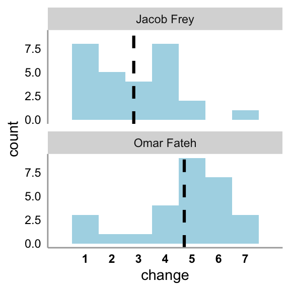

```r
means <- df_lebe_elg %>%
  filter(PLACENAME == "Minneapolis") %>%
  select(PID,CAND_1:CAND_2,cand1_change,cand2_change) %>%
  pivot_longer(-c(PID,cand1_change,cand2_change),
               names_to = "names",
               values_to = "candidate") %>%
  mutate(change = ifelse(names == "CAND_1",cand1_change,cand2_change)) %>%
  select(PID,candidate,change) %>%
  group_by(candidate) %>%
  summarise(score = mean(change,na.rm = T)) %>%
  ungroup()

df_lebe_elg %>%
  filter(PLACENAME == "Minneapolis") %>%
  select(PID,CAND_1:CAND_2,cand1_change,cand2_change) %>%
  pivot_longer(-c(PID,cand1_change,cand2_change),
               names_to = "names",
               values_to = "candidate") %>%
  mutate(change = ifelse(names == "CAND_1",cand1_change,cand2_change)) %>%
  select(PID,candidate,change) %>%
  ggplot() +
  geom_histogram(aes(x = change),
                 fill = "lightblue",
                 color = NA,
                 binwidth = 1) +
  scale_x_continuous(limits = c(0,8),
                     breaks = seq(1,7,1)) +
  geom_vline(data = means,mapping = aes(xintercept = score),
             color = "black",
             linetype = "dashed",
             size = 1.1) +
  theme(panel.grid.major = element_blank(),
        panel.grid.minor = element_blank(),
        panel.background = element_blank(),
        axis.ticks = element_blank(),
        axis.line = element_line(color = "grey66"),
        axis.text.y = element_text(color = "black"),
        axis.text.x = element_text(color = "black",
                                   face = "bold")) +
  facet_wrap(~candidate,nrow = 2)
```

### Cultural issues

What is their approach to cultural issues? Broadly, they may have a more **progressive approach** to cultural issues (pro-choice, minority rights, inclusive immigration) or a more **conservative approach** to cultural issues (pro-life, stronger police, immigration crackdown). (1 = *Progressive* to 7 = *Conservative*)

```r
df_lebe_elg %>%
  filter(PLACENAME == "Minneapolis") %>%
  select(PID,CAND_1:CAND_2,cand1_cult,cand2_cult) %>%
  pivot_longer(-c(PID,cand1_cult,cand2_cult),
               names_to = "names",
               values_to = "candidate") %>%
  mutate(cult = ifelse(names == "CAND_1",cand1_cult,cand2_cult)) %>%
  select(PID,candidate,cult) %>%
  group_by(candidate) %>%
  summarise(n = n(),
            mean = mean(cult,na.rm = T),
            sd = sd(cult,na.rm = T)) %>%
  ungroup() %>%
  kbl() %>%
  kable_styling(bootstrap_options = "hover",
                full_width = F,
                position = "left")
```

| candidate | n | mean | sd |
| --- | --- | --- | --- |
| Jacob Frey | 28 | 3.642857 | 1.544747 |
| Omar Fateh | 28 | 2.035714 | 1.373887 |

```r
formodel <- df_lebe_elg %>%
  filter(PLACENAME == "Minneapolis") %>%
  select(PID,CAND_1:CAND_2,cand1_cult,cand2_cult) %>%
  pivot_longer(-c(PID,cand1_cult,cand2_cult),
               names_to = "names",
               values_to = "candidate") %>%
  mutate(cult = ifelse(names == "CAND_1",cand1_cult,cand2_cult)) %>%
  select(PID,candidate,cult)

m1 <- rstatix::t_test(cult ~ candidate,data = formodel,paired = T,detailed = T)
m2 <- rstatix::cohens_d(formodel,cult ~ candidate,paired = T)

d = round(m2$effsize,2)

m1 %>%
  select(statistic,df,p,conf.low,conf.high) %>%
  mutate(d = d) %>%
    kbl() %>%
  kable_styling(bootstrap_options = "hover",
                full_width = F,
                position = "left")
```

| statistic | df | p | conf.low | conf.high | d |
| --- | --- | --- | --- | --- | --- |
| 4.448401 | 27 | 0.000134 | 0.8658462 | 2.34844 | 0.84 |

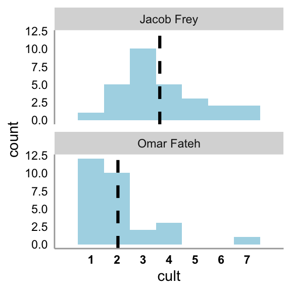

```r
means <- df_lebe_elg %>%
  filter(PLACENAME == "Minneapolis") %>%
  select(PID,CAND_1:CAND_2,cand1_cult,cand2_cult) %>%
  pivot_longer(-c(PID,cand1_cult,cand2_cult),
               names_to = "names",
               values_to = "candidate") %>%
  mutate(cult = ifelse(names == "CAND_1",cand1_cult,cand2_cult)) %>%
  select(PID,candidate,cult) %>%
  group_by(candidate) %>%
  summarise(score = mean(cult,na.rm = T)) %>%
  ungroup()

df_lebe_elg %>%
  filter(PLACENAME == "Minneapolis") %>%
  select(PID,CAND_1:CAND_2,cand1_cult,cand2_cult) %>%
  pivot_longer(-c(PID,cand1_cult,cand2_cult),
               names_to = "names",
               values_to = "candidate") %>%
  mutate(cult = ifelse(names == "CAND_1",cand1_cult,cand2_cult)) %>%
  select(PID,candidate,cult) %>%
  ggplot() +
  geom_histogram(aes(x = cult),
                 fill = "lightblue",
                 color = NA,
                 binwidth = 1) +
  scale_x_continuous(limits = c(0,8),
                     breaks = seq(1,7,1)) +
  geom_vline(data = means,mapping = aes(xintercept = score),
             color = "black",
             linetype = "dashed",
             size = 1.1) +
  theme(panel.grid.major = element_blank(),
        panel.grid.minor = element_blank(),
        panel.background = element_blank(),
        axis.ticks = element_blank(),
        axis.line = element_line(color = "grey66"),
        axis.text.y = element_text(color = "black"),
        axis.text.x = element_text(color = "black",
                                   face = "bold")) +
  facet_wrap(~candidate,nrow = 2)
```

### Economic policy

What is their approach to economic policy? Broadly, they may be supportive of more **redistributive** economic policies (high corporate taxes, stronger unions, welfare funding) or more **free-market** economic policies (low corporate taxes, deregulation, reducing government budget). (1 = *Redistributive* to 7 = *Free Market*)

```r
df_lebe_elg %>%
  filter(PLACENAME == "Minneapolis") %>%
  select(PID,CAND_1:CAND_2,cand1_econ,cand2_econ) %>%
  pivot_longer(-c(PID,cand1_econ,cand2_econ),
               names_to = "names",
               values_to = "candidate") %>%
  mutate(econ = ifelse(names == "CAND_1",cand1_econ,cand2_econ)) %>%
  select(PID,candidate,econ) %>%
  group_by(candidate) %>%
  summarise(n = n(),
            mean = mean(econ,na.rm = T),
            sd = sd(econ,na.rm = T)) %>%
  ungroup() %>%
  kbl() %>%
  kable_styling(bootstrap_options = "hover",
                full_width = F,
                position = "left")
```

| candidate | n | mean | sd |
| --- | --- | --- | --- |
| Jacob Frey | 28 | 4.321429 | 1.362285 |
| Omar Fateh | 28 | 2.928571 | 1.719788 |

```r
formodel <- df_lebe_elg %>%
  filter(PLACENAME == "Minneapolis") %>%
  select(PID,CAND_1:CAND_2,cand1_econ,cand2_econ) %>%
  pivot_longer(-c(PID,cand1_econ,cand2_econ),
               names_to = "names",
               values_to = "candidate") %>%
  mutate(econ = ifelse(names == "CAND_1",cand1_econ,cand2_econ)) %>%
  select(PID,candidate,econ)

m1 <- rstatix::t_test(econ ~ candidate,data = formodel,paired = T,detailed = T)
m2 <- rstatix::cohens_d(formodel,econ ~ candidate,paired = T)

d = round(m2$effsize,2)

m1 %>%
  select(statistic,df,p,conf.low,conf.high) %>%
  mutate(d = d) %>%
    kbl() %>%
  kable_styling(bootstrap_options = "hover",
                full_width = F,
                position = "left")
```

| statistic | df | p | conf.low | conf.high | d |
| --- | --- | --- | --- | --- | --- |
| 3.673631 | 27 | 0.00104 | 0.6149056 | 2.170809 | 0.69 |

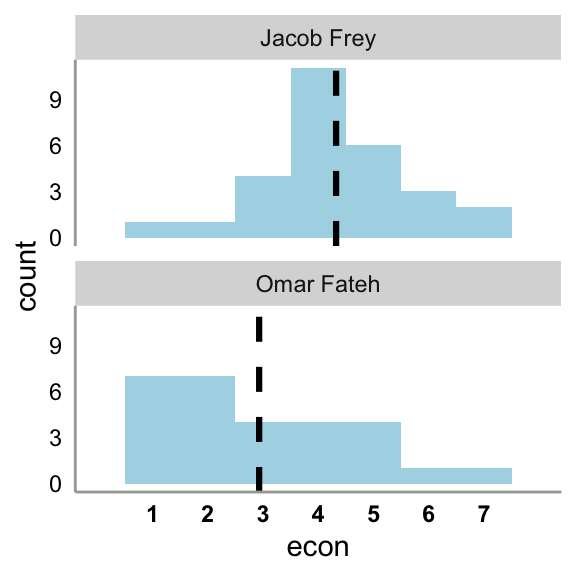

```r
means <- df_lebe_elg %>%
  filter(PLACENAME == "Minneapolis") %>%
  select(PID,CAND_1:CAND_2,cand1_econ,cand2_econ) %>%
  pivot_longer(-c(PID,cand1_econ,cand2_econ),
               names_to = "names",
               values_to = "candidate") %>%
  mutate(econ = ifelse(names == "CAND_1",cand1_econ,cand2_econ)) %>%
  select(PID,candidate,econ) %>%
  group_by(candidate) %>%
  summarise(score = mean(econ,na.rm = T)) %>%
  ungroup()

df_lebe_elg %>%
  filter(PLACENAME == "Minneapolis") %>%
  select(PID,CAND_1:CAND_2,cand1_econ,cand2_econ) %>%
  pivot_longer(-c(PID,cand1_econ,cand2_econ),
               names_to = "names",
               values_to = "candidate") %>%
  mutate(econ = ifelse(names == "CAND_1",cand1_econ,cand2_econ)) %>%
  select(PID,candidate,econ) %>%
  ggplot() +
  geom_histogram(aes(x = econ),
                 fill = "lightblue",
                 color = NA,
                 binwidth = 1) +
  scale_x_continuous(limits = c(0,8),
                     breaks = seq(1,7,1)) +
  geom_vline(data = means,mapping = aes(xintercept = score),
             color = "black",
             linetype = "dashed",
             size = 1.1) +
  theme(panel.grid.major = element_blank(),
        panel.grid.minor = element_blank(),
        panel.background = element_blank(),
        axis.ticks = element_blank(),
        axis.line = element_line(color = "grey66"),
        axis.text.y = element_text(color = "black"),
        axis.text.x = element_text(color = "black",
                                   face = "bold")) +
  facet_wrap(~candidate,nrow = 2)
```

## Cleveland

### Approach to change

For each candidate, would you describe them as promising a **minor, incremental, and modest** change to how things are done in [PLACENAME] [state/city] government, or a **major, sweeping, and drastic** change in how things are done in [PLACENAME] [state/city] government? (1 = *Incremental* to 7 = *Sweeping*)

```r
df_lebe_elg %>%
  filter(PLACENAME == "Cleveland") %>%
  select(PID,CAND_1:CAND_2,cand1_change,cand2_change) %>%
  pivot_longer(-c(PID,cand1_change,cand2_change),
               names_to = "names",
               values_to = "candidate") %>%
  mutate(change = ifelse(names == "CAND_1",cand1_change,cand2_change)) %>%
  select(PID,candidate,change) %>%
  group_by(candidate) %>%
  summarise(n = n(),
            mean = mean(change,na.rm = T),
            sd = sd(change,na.rm = T)) %>%
  ungroup() %>%
  kbl() %>%
  kable_styling(bootstrap_options = "hover",
                full_width = F,
                position = "left")
```

| candidate | n | mean | sd |
| --- | --- | --- | --- |
| Justin Bibb | 17 | 4.529412 | 1.736291 |
| Laverne Gore | 17 | 4.117647 | 1.268974 |

```r
formodel <- df_lebe_elg %>%
  filter(PLACENAME == "Cleveland") %>%
  select(PID,CAND_1:CAND_2,cand1_change,cand2_change) %>%
  pivot_longer(-c(PID,cand1_change,cand2_change),
               names_to = "names",
               values_to = "candidate") %>%
  mutate(change = ifelse(names == "CAND_1",cand1_change,cand2_change)) %>%
  select(PID,candidate,change)

m1 <- rstatix::t_test(change ~ candidate,data = formodel,paired = T,detailed = T)
m2 <- rstatix::cohens_d(formodel,change ~ candidate,paired = T)

d = round(m2$effsize,2)

m1 %>%
  select(statistic,df,p,conf.low,conf.high) %>%
  mutate(d = d) %>%
    kbl() %>%
  kable_styling(bootstrap_options = "hover",
                full_width = F,
                position = "left")
```

| statistic | df | p | conf.low | conf.high | d |
| --- | --- | --- | --- | --- | --- |
| 0.7494028 | 16 | 0.464 | -0.7530323 | 1.576562 | 0.18 |

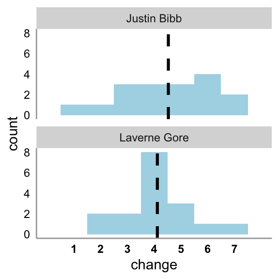

```r
means <- df_lebe_elg %>%
  filter(PLACENAME == "Cleveland") %>%
  select(PID,CAND_1:CAND_2,cand1_change,cand2_change) %>%
  pivot_longer(-c(PID,cand1_change,cand2_change),
               names_to = "names",
               values_to = "candidate") %>%
  mutate(change = ifelse(names == "CAND_1",cand1_change,cand2_change)) %>%
  select(PID,candidate,change) %>%
  group_by(candidate) %>%
  summarise(score = mean(change,na.rm = T)) %>%
  ungroup()

df_lebe_elg %>%
  filter(PLACENAME == "Cleveland") %>%
  select(PID,CAND_1:CAND_2,cand1_change,cand2_change) %>%
  pivot_longer(-c(PID,cand1_change,cand2_change),
               names_to = "names",
               values_to = "candidate") %>%
  mutate(change = ifelse(names == "CAND_1",cand1_change,cand2_change)) %>%
  select(PID,candidate,change) %>%
  ggplot() +
  geom_histogram(aes(x = change),
                 fill = "lightblue",
                 color = NA,
                 binwidth = 1) +
  scale_x_continuous(limits = c(0,8),
                     breaks = seq(1,7,1)) +
  geom_vline(data = means,mapping = aes(xintercept = score),
             color = "black",
             linetype = "dashed",
             size = 1.1) +
  theme(panel.grid.major = element_blank(),
        panel.grid.minor = element_blank(),
        panel.background = element_blank(),
        axis.ticks = element_blank(),
        axis.line = element_line(color = "grey66"),
        axis.text.y = element_text(color = "black"),
        axis.text.x = element_text(color = "black",
                                   face = "bold")) +
  facet_wrap(~candidate,nrow = 2)
```

### Cultural issues

What is their approach to cultural issues? Broadly, they may have a more **progressive approach** to cultural issues (pro-choice, minority rights, inclusive immigration) or a more **conservative approach** to cultural issues (pro-life, stronger police, immigration crackdown). (1 = *Progressive* to 7 = *Conservative*)

```r
df_lebe_elg %>%
  filter(PLACENAME == "Cleveland") %>%
  select(PID,CAND_1:CAND_2,cand1_cult,cand2_cult) %>%
  pivot_longer(-c(PID,cand1_cult,cand2_cult),
               names_to = "names",
               values_to = "candidate") %>%
  mutate(cult = ifelse(names == "CAND_1",cand1_cult,cand2_cult)) %>%
  select(PID,candidate,cult) %>%
  group_by(candidate) %>%
  summarise(n = n(),
            mean = mean(cult,na.rm = T),
            sd = sd(cult,na.rm = T)) %>%
  ungroup() %>%
  kbl() %>%
  kable_styling(bootstrap_options = "hover",
                full_width = F,
                position = "left")
```

| candidate | n | mean | sd |
| --- | --- | --- | --- |
| Justin Bibb | 17 | 1.941177 | 0.9663455 |
| Laverne Gore | 17 | 5.294118 | 1.2126781 |

```r
formodel <- df_lebe_elg %>%
  filter(PLACENAME == "Cleveland") %>%
  select(PID,CAND_1:CAND_2,cand1_cult,cand2_cult) %>%
  pivot_longer(-c(PID,cand1_cult,cand2_cult),
               names_to = "names",
               values_to = "candidate") %>%
  mutate(cult = ifelse(names == "CAND_1",cand1_cult,cand2_cult)) %>%
  select(PID,candidate,cult)

m1 <- rstatix::t_test(cult ~ candidate,data = formodel,paired = T,detailed = T)
m2 <- rstatix::cohens_d(formodel,cult ~ candidate,paired = T)

d = round(m2$effsize,2)

m1 %>%
  select(statistic,df,p,conf.low,conf.high) %>%
  mutate(d = d) %>%
    kbl() %>%
  kable_styling(bootstrap_options = "hover",
                full_width = F,
                position = "left")
```

| statistic | df | p | conf.low | conf.high | d |
| --- | --- | --- | --- | --- | --- |
| -7.829552 | 16 | 7e-07 | -4.260773 | -2.445109 | -1.9 |

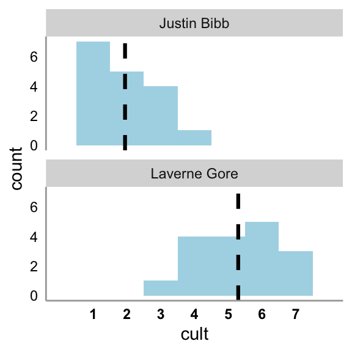

```r
means <- df_lebe_elg %>%
  filter(PLACENAME == "Cleveland") %>%
  select(PID,CAND_1:CAND_2,cand1_cult,cand2_cult) %>%
  pivot_longer(-c(PID,cand1_cult,cand2_cult),
               names_to = "names",
               values_to = "candidate") %>%
  mutate(cult = ifelse(names == "CAND_1",cand1_cult,cand2_cult)) %>%
  select(PID,candidate,cult) %>%
  group_by(candidate) %>%
  summarise(score = mean(cult,na.rm = T)) %>%
  ungroup()

df_lebe_elg %>%
  filter(PLACENAME == "Cleveland") %>%
  select(PID,CAND_1:CAND_2,cand1_cult,cand2_cult) %>%
  pivot_longer(-c(PID,cand1_cult,cand2_cult),
               names_to = "names",
               values_to = "candidate") %>%
  mutate(cult = ifelse(names == "CAND_1",cand1_cult,cand2_cult)) %>%
  select(PID,candidate,cult) %>%
  ggplot() +
  geom_histogram(aes(x = cult),
                 fill = "lightblue",
                 color = NA,
                 binwidth = 1) +
  scale_x_continuous(limits = c(0,8),
                     breaks = seq(1,7,1)) +
  geom_vline(data = means,mapping = aes(xintercept = score),
             color = "black",
             linetype = "dashed",
             size = 1.1) +
  theme(panel.grid.major = element_blank(),
        panel.grid.minor = element_blank(),
        panel.background = element_blank(),
        axis.ticks = element_blank(),
        axis.line = element_line(color = "grey66"),
        axis.text.y = element_text(color = "black"),
        axis.text.x = element_text(color = "black",
                                   face = "bold")) +
  facet_wrap(~candidate,nrow = 2)
```

### Economic policy

What is their approach to economic policy? Broadly, they may be supportive of more **redistributive** economic policies (high corporate taxes, stronger unions, welfare funding) or more **free-market** economic policies (low corporate taxes, deregulation, reducing government budget). (1 = *Redistributive* to 7 = *Free Market*)

```r
df_lebe_elg %>%
  filter(PLACENAME == "Cleveland") %>%
  select(PID,CAND_1:CAND_2,cand1_econ,cand2_econ) %>%
  pivot_longer(-c(PID,cand1_econ,cand2_econ),
               names_to = "names",
               values_to = "candidate") %>%
  mutate(econ = ifelse(names == "CAND_1",cand1_econ,cand2_econ)) %>%
  select(PID,candidate,econ) %>%
  group_by(candidate) %>%
  summarise(n = n(),
            mean = mean(econ,na.rm = T),
            sd = sd(econ,na.rm = T)) %>%
  ungroup() %>%
  kbl() %>%
  kable_styling(bootstrap_options = "hover",
                full_width = F,
                position = "left")
```

| candidate | n | mean | sd |
| --- | --- | --- | --- |
| Justin Bibb | 17 | 3.764706 | 1.751050 |
| Laverne Gore | 17 | 4.470588 | 1.699914 |

```r
formodel <- df_lebe_elg %>%
  filter(PLACENAME == "Cleveland") %>%
  select(PID,CAND_1:CAND_2,cand1_econ,cand2_econ) %>%
  pivot_longer(-c(PID,cand1_econ,cand2_econ),
               names_to = "names",
               values_to = "candidate") %>%
  mutate(econ = ifelse(names == "CAND_1",cand1_econ,cand2_econ)) %>%
  select(PID,candidate,econ)

m1 <- rstatix::t_test(econ ~ candidate,data = formodel,paired = T,detailed = T)
m2 <- rstatix::cohens_d(formodel,econ ~ candidate,paired = T)

d = round(m2$effsize,2)

m1 %>%
  select(statistic,df,p,conf.low,conf.high) %>%
  mutate(d = d) %>%
    kbl() %>%
  kable_styling(bootstrap_options = "hover",
                full_width = F,
                position = "left")
```

| statistic | df | p | conf.low | conf.high | d |
| --- | --- | --- | --- | --- | --- |
| -0.9048554 | 16 | 0.379 | -2.359631 | 0.9478666 | -0.22 |

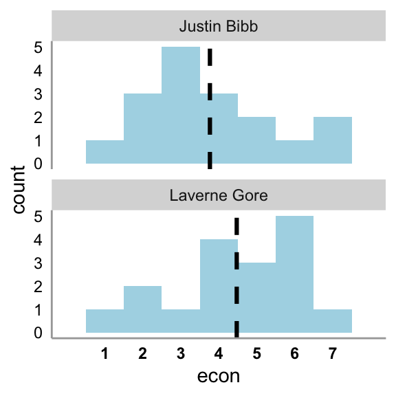

```r
means <- df_lebe_elg %>%
  filter(PLACENAME == "Cleveland") %>%
  select(PID,CAND_1:CAND_2,cand1_econ,cand2_econ) %>%
  pivot_longer(-c(PID,cand1_econ,cand2_econ),
               names_to = "names",
               values_to = "candidate") %>%
  mutate(econ = ifelse(names == "CAND_1",cand1_econ,cand2_econ)) %>%
  select(PID,candidate,econ) %>%
  group_by(candidate) %>%
  summarise(score = mean(econ,na.rm = T)) %>%
  ungroup()

df_lebe_elg %>%
  filter(PLACENAME == "Cleveland") %>%
  select(PID,CAND_1:CAND_2,cand1_econ,cand2_econ) %>%
  pivot_longer(-c(PID,cand1_econ,cand2_econ),
               names_to = "names",
               values_to = "candidate") %>%
  mutate(econ = ifelse(names == "CAND_1",cand1_econ,cand2_econ)) %>%
  select(PID,candidate,econ) %>%
  ggplot() +
  geom_histogram(aes(x = econ),
                 fill = "lightblue",
                 color = NA,
                 binwidth = 1) +
  scale_x_continuous(limits = c(0,8),
                     breaks = seq(1,7,1)) +
  geom_vline(data = means,mapping = aes(xintercept = score),
             color = "black",
             linetype = "dashed",
             size = 1.1) +
  theme(panel.grid.major = element_blank(),
        panel.grid.minor = element_blank(),
        panel.background = element_blank(),
        axis.ticks = element_blank(),
        axis.line = element_line(color = "grey66"),
        axis.text.y = element_text(color = "black"),
        axis.text.x = element_text(color = "black",
                                   face = "bold")) +
  facet_wrap(~candidate,nrow = 2)
```

# Voting intentions

## New Jersey

### Turnout

```r
df_lebe_elg %>%
  filter(STATE == "New Jersey") %>%
  group_by(vote_turnout) %>%
  summarise(N = n()) %>%
  ungroup() %>%
  mutate(Perc = round(100*(N/sum(N)),2)) %>%
  ungroup() %>%
  arrange(desc(N)) %>%
  kbl() %>%
  kable_styling(bootstrap_options = "hover",
                full_width = F,
                position = "left")
```

| vote_turnout | N | Perc |
| --- | --- | --- |
| Yes | 30 | 60 |
| Not sure | 12 | 24 |
| No | 8 | 16 |

### Who

```r
df_lebe_elg %>%
  filter(STATE == "New Jersey") %>%
  group_by(vote_who) %>%
  summarise(N = n()) %>%
  ungroup() %>%
  mutate(Perc = round(100*(N/sum(N)),2)) %>%
  ungroup() %>%
  arrange(desc(N)) %>%
  kbl() %>%
  kable_styling(bootstrap_options = "hover",
                full_width = F,
                position = "left")
```

| vote_who | N | Perc |
| --- | --- | --- |
| Mikie Sherill | 26 | 52 |
| NA | 13 | 26 |
| Jack Ciattarelli | 10 | 20 |
| neither | 1 | 2 |

## Virginia

### Turnout

```r
df_lebe_elg %>%
  filter(STATE == "Virginia") %>%
  group_by(vote_turnout) %>%
  summarise(N = n()) %>%
  ungroup() %>%
  mutate(Perc = round(100*(N/sum(N)),2)) %>%
  ungroup() %>%
  arrange(desc(N)) %>%
  kbl() %>%
  kable_styling(bootstrap_options = "hover",
                full_width = F,
                position = "left")
```

| vote_turnout | N | Perc |
| --- | --- | --- |
| Yes | 42 | 85.71 |
| Not sure | 4 | 8.16 |
| No | 3 | 6.12 |

### Who

```r
df_lebe_elg %>%
  filter(STATE == "Virginia") %>%
  group_by(vote_who) %>%
  summarise(N = n()) %>%
  ungroup() %>%
  mutate(Perc = round(100*(N/sum(N)),2)) %>%
  ungroup() %>%
  arrange(desc(N)) %>%
  kbl() %>%
  kable_styling(bootstrap_options = "hover",
                full_width = F,
                position = "left")
```

| vote_who | N | Perc |
| --- | --- | --- |
| Abigail Spanberger | 31 | 63.27 |
| Winsome Earle-Sears | 15 | 30.61 |
| NA | 3 | 6.12 |

## New York City

### Turnout

```r
df_lebe_elg %>%
  filter(PLACENAME == "New York City") %>%
  group_by(vote_turnout) %>%
  summarise(N = n()) %>%
  ungroup() %>%
  mutate(Perc = round(100*(N/sum(N)),2)) %>%
  ungroup() %>%
  arrange(desc(N)) %>%
  kbl() %>%
  kable_styling(bootstrap_options = "hover",
                full_width = F,
                position = "left")
```

| vote_turnout | N | Perc |
| --- | --- | --- |
| Yes | 38 | 79.17 |
| Not sure | 6 | 12.50 |
| No | 4 | 8.33 |

### Who

```r
df_lebe_elg %>%
  filter(PLACENAME == "New York City") %>%
  group_by(vote_who) %>%
  summarise(N = n()) %>%
  ungroup() %>%
  mutate(Perc = round(100*(N/sum(N)),2)) %>%
  ungroup() %>%
  arrange(desc(N)) %>%
  kbl() %>%
  kable_styling(bootstrap_options = "hover",
                full_width = F,
                position = "left")
```

| vote_who | N | Perc |
| --- | --- | --- |
| Zohran Mamdani | 37 | 77.08 |
| Andrew Cuomo | 6 | 12.50 |
| NA | 4 | 8.33 |
| Curtis Sliwa | 1 | 2.08 |

## Seattle

### Turnout

```r
df_lebe_elg %>%
  filter(PLACENAME == "Seattle") %>%
  group_by(vote_turnout) %>%
  summarise(N = n()) %>%
  ungroup() %>%
  mutate(Perc = round(100*(N/sum(N)),2)) %>%
  ungroup() %>%
  arrange(desc(N)) %>%
  kbl() %>%
  kable_styling(bootstrap_options = "hover",
                full_width = F,
                position = "left")
```

| vote_turnout | N | Perc |
| --- | --- | --- |
| Yes | 16 | 55.17 |
| Not sure | 7 | 24.14 |
| No | 6 | 20.69 |

### Who

```r
df_lebe_elg %>%
  filter(PLACENAME == "Seattle") %>%
  group_by(vote_who) %>%
  summarise(N = n()) %>%
  ungroup() %>%
  mutate(Perc = round(100*(N/sum(N)),2)) %>%
  ungroup() %>%
  arrange(desc(N)) %>%
  kbl() %>%
  kable_styling(bootstrap_options = "hover",
                full_width = F,
                position = "left")
```

| vote_who | N | Perc |
| --- | --- | --- |
| Katie Wilson | 12 | 41.38 |
| Bruce Harrell | 9 | 31.03 |
| NA | 7 | 24.14 |
| Anyone who is more conservative than these two socialists. | 1 | 3.45 |

## Minneapolis

### Turnout

```r
df_lebe_elg %>%
  filter(PLACENAME == "Minneapolis") %>%
  group_by(vote_turnout) %>%
  summarise(N = n()) %>%
  ungroup() %>%
  mutate(Perc = round(100*(N/sum(N)),2)) %>%
  ungroup() %>%
  arrange(desc(N)) %>%
  kbl() %>%
  kable_styling(bootstrap_options = "hover",
                full_width = F,
                position = "left")
```

| vote_turnout | N | Perc |
| --- | --- | --- |
| Yes | 17 | 60.71 |
| No | 6 | 21.43 |
| Not sure | 5 | 17.86 |

### Who

```r
df_lebe_elg %>%
  filter(PLACENAME == "Minneapolis") %>%
  group_by(vote_who) %>%
  summarise(N = n()) %>%
  ungroup() %>%
  mutate(Perc = round(100*(N/sum(N)),2)) %>%
  ungroup() %>%
  arrange(desc(N)) %>%
  kbl() %>%
  kable_styling(bootstrap_options = "hover",
                full_width = F,
                position = "left")
```

| vote_who | N | Perc |
| --- | --- | --- |
| Jacob Frey | 14 | 50.00 |
| Omar Fateh | 8 | 28.57 |
| NA | 5 | 17.86 |
| Whoever is the Republican. | 1 | 3.57 |

## Cleveland

### Turnout

```r
df_lebe_elg %>%
  filter(PLACENAME == "Cleveland") %>%
  group_by(vote_turnout) %>%
  summarise(N = n()) %>%
  ungroup() %>%
  mutate(Perc = round(100*(N/sum(N)),2)) %>%
  ungroup() %>%
  arrange(desc(N)) %>%
  kbl() %>%
  kable_styling(bootstrap_options = "hover",
                full_width = F,
                position = "left")
```

| vote_turnout | N | Perc |
| --- | --- | --- |
| Yes | 9 | 52.94 |
| No | 6 | 35.29 |
| Not sure | 2 | 11.76 |

### Who

```r
df_lebe_elg %>%
  filter(PLACENAME == "Cleveland") %>%
  group_by(vote_who) %>%
  summarise(N = n()) %>%
  ungroup() %>%
  mutate(Perc = round(100*(N/sum(N)),2)) %>%
  ungroup() %>%
  arrange(desc(N)) %>%
  kbl() %>%
  kable_styling(bootstrap_options = "hover",
                full_width = F,
                position = "left")
```

| vote_who | N | Perc |
| --- | --- | --- |
| Justin Bibb | 9 | 52.94 |
| Laverne Gore | 5 | 29.41 |
| NA | 2 | 11.76 |
| I would vote for Justin Bibb, but while I live in Cuyahoga County, I do not live in Cleveland. | 1 | 5.88 |